# Análisis del Presupuesto funcional de los ingresos del Ayuntamiento de Alcobendas 2022

## Columnas

A continuación mostramos el nombre de las columnas a través de df.columns (en los datos que hemos escogido hay pocas columnas)

```python
df.columns
```

```
Index(['Código', 'Nombre', 'Crédito inicial del ejercicio'], dtype='object')
```

## Enseñar las variables

Ahora usamos df_es.describe() para enseñar las variables de nuestra tabla.

```python
df.describe()
```

|  | Código | Crédito inicial del ejercicio |
| --- | --- | --- |
| count | 329.000000 | 3.300000e+02 |
| mean | 403.929514 | 2.415529e+06 |
| std | 275.541759 | 1.270834e+07 |
| min | 1.000000 | 0.000000e+00 |
| 25% | 115.000000 | 0.000000e+00 |
| 50% | 394.000000 | 0.000000e+00 |
| 75% | 600.000000 | 1.892133e+05 |
| max | 941.000000 | 1.911289e+08 |

## A continuación vamos a ordenar (indexar) basándonos en una columna

Lo haremos a través de a variable "Código"

```python
df.set_index('Código')
```

| Código | Nombre | Crédito inicial del ejercicio |
| --- | --- | --- |
| NaN | Clasificación económica de ingresos | 1.911289e+08 |
| 1.0 | IMPUESTOS DIRECTOS | 7.930614e+07 |
| 10.0 | Impuesto sobre la Renta | 9.432241e+06 |
| 100.0 | Impuestos sobre la Renta de las Personas Físicas | 9.432241e+06 |
| 101.0 | Impuesto sobre Sociedades | 0.000000e+00 |
| ... | ... | ... |
| 930.0 | Préstamos recibidos en moneda distinta del eur... | 0.000000e+00 |
| 931.0 | Préstamos recibidos en moneda distinta del eur... | 0.000000e+00 |
| 94.0 | Depósitos y fianzas recibidos | 0.000000e+00 |
| 940.0 | Depósitos recibidos | 0.000000e+00 |
| 941.0 | Fianzas recibidas | 0.000000e+00 |

330 rows × 2 columns

```python
df.set_index('Código')['Crédito inicial del ejercicio']
```

```
Código
NaN      1.911289e+08
1.0      7.930614e+07
10.0     9.432241e+06
100.0    9.432241e+06
101.0    0.000000e+00
             ...
930.0    0.000000e+00
931.0    0.000000e+00
94.0     0.000000e+00
940.0    0.000000e+00
941.0    0.000000e+00
Name: Crédito inicial del ejercicio, Length: 330, dtype: float64
```

Ahora vamos a intentar crear un gráfico a través de esas dos variables

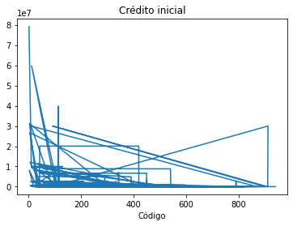

```python
df.set_index('Código')['Crédito inicial del ejercicio'].plot(title="Crédito inicial")
```

Se ha creado aunque soy incapaz de entender el gráfico

```python
from matplotlib import pyplot as plt
```

```
<BarContainer object of 330 artists>
```

[figure not shown]

```python
plt.bar(df["Código"], df["Crédito inicial del ejercicio"])
```

```
<BarContainer object of 330 artists>
```

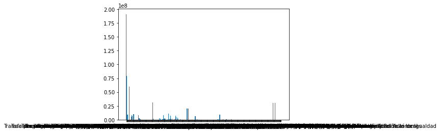

```python
plt.bar(range(len(df['Crédito inicial del ejercicio'])), df['Crédito inicial del ejercicio'], tick_label=df['Nombre'])
```

Vamos a volver a empezar con unos datos nuevos en vista de que no hay columnas suficientes.

# Análisis de la distribución de las personas beneficiarias de prestación económica o servicio por grado de dependencia en Catalunya

Vamos a seguir los mismos pasos anteriores

```python
!pip install pandas
```

```python
import pandas as pd
```

```python
df = pd.read_csv('./Distribuci__de_les_persones_benefici_ries_de_prestaci__econ_mica_o_servei_per_grau_de_depend_ncia.csv')
```

```python
df
```

|  | Any | Codi | Comarca | Dones grau III | Homes grau III | Total grau III | Dones grau II | Homes grau II | Total grau II | Dones grau I | Homes grau I | Total grau I | Dones | Homes | Total |
| --- | --- | --- | --- | --- | --- | --- | --- | --- | --- | --- | --- | --- | --- | --- | --- |
| 0 | 2015 | 1 | Alt Camp | 170.000 | 96.000 | 266.000 | 263.000 | 140.000 | 403.000 | 60.000 | 44.000 | 104.000 | 493.000 | 280.000 | 773.000 |
| 1 | 2015 | 2 | Alt Empordà | 541.000 | 297.000 | 838.000 | 816.000 | 479.000 | 1295.000 | 155.000 | 78.000 | 233.000 | 1512.000 | 854.000 | 2366.000 |
| 2 | 2015 | 3 | Alt Penedès | 513.000 | 312.000 | 825.000 | 741.000 | 395.000 | 1136.000 | 137.000 | 56.000 | 193.000 | 1391.000 | 763.000 | 2154.000 |
| 3 | 2015 | 4 | Alt Urgell | 124.000 | 62.000 | 186.000 | 224.000 | 126.000 | 350.000 | 19.000 | 13.000 | 32.000 | 367.000 | 201.000 | 568.000 |
| 4 | 2015 | 5 | Alta Ribagorça | 23.000 | 10.000 | 33.000 | 37.000 | 17.000 | 54.000 | 6.000 | 3.000 | 9.000 | 66.000 | 30.000 | 96.000 |
| ... | ... | ... | ... | ... | ... | ... | ... | ... | ... | ... | ... | ... | ... | ... | ... |
| 289 | 2021 | 38 | Tarragonès | 504.000 | 312.000 | 816.000 | 1.270 | 662.000 | 1.932 | 1.409 | 811.000 | 2.220 | 3.183 | 1.785 | 4.968 |
| 290 | 2021 | 39 | Terra Alta | 76.000 | 41.000 | 117.000 | 165.000 | 84.000 | 249.000 | 200.000 | 82.000 | 282.000 | 441.000 | 207.000 | 648.000 |
| 291 | 2021 | 40 | Urgell | 197.000 | 92.000 | 289.000 | 270.000 | 139.000 | 409.000 | 203.000 | 134.000 | 337.000 | 670.000 | 365.000 | 1.035 |
| 292 | 2021 | 41 | Vallès Occidental | 3.099 | 1.903 | 5.002 | 5.040 | 2.937 | 7.977 | 5.050 | 2.607 | 7.657 | 13.189 | 7.447 | 20.636 |
| 293 | 2021 | 42 | Vallès Oriental | 1.400 | 771.000 | 2.171 | 2.126 | 1.275 | 3.401 | 1.921 | 1.100 | 3.021 | 5.447 | 3.146 | 8.593 |

294 rows × 15 columns

```python
df.info()
```

```
<class 'pandas.core.frame.DataFrame'>
RangeIndex: 294 entries, 0 to 293
Data columns (total 15 columns):
 #   Column          Non-Null Count  Dtype
---  ------          --------------  -----
 0   Any             294 non-null    int64
 1   Codi            294 non-null    int64
 2   Comarca         294 non-null    object
 3   Dones grau III  294 non-null    float64
 4   Homes grau III  294 non-null    float64
 5   Total grau III  294 non-null    float64
 6   Dones grau II   294 non-null    float64
 7   Homes grau II   294 non-null    float64
 8   Total grau II   294 non-null    float64
 9   Dones grau I    294 non-null    float64
 10  Homes grau I    294 non-null    float64
 11  Total grau I    294 non-null    float64
 12  Dones           294 non-null    float64
 13  Homes           294 non-null    float64
 14  Total           294 non-null    float64
dtypes: float64(12), int64(2), object(1)
memory usage: 34.6+ KB
```

Hacemos de nuevo esto para mostrar las nuevas variables.

```python
df.describe
```

```
<bound method NDFrame.describe of       Any  Codi            Comarca  Dones grau III  Homes grau III  \
0    2015     1           Alt Camp         170.000          96.000
1    2015     2        Alt Empordà         541.000         297.000
2    2015     3        Alt Penedès         513.000         312.000
3    2015     4         Alt Urgell         124.000          62.000
4    2015     5     Alta Ribagorça          23.000          10.000
..    ...   ...                ...             ...             ...
289  2021    38         Tarragonès         504.000         312.000
290  2021    39         Terra Alta          76.000          41.000
291  2021    40             Urgell         197.000          92.000
292  2021    41  Vallès Occidental           3.099           1.903
293  2021    42    Vallès Oriental           1.400         771.000

     Total grau III  Dones grau II  Homes grau II  Total grau II  \
0           266.000        263.000        140.000        403.000
```

[output cut: 25 more lines]

A continuación vemos los nombres de las columnas que hay en la tabla. En esta ocasión y con estos datos, vemos que con numerables.

```python
df.columns
```

```
Index(['Any', 'Codi', 'Comarca', 'Dones grau III', 'Homes grau III',
       'Total grau III', 'Dones grau II', 'Homes grau II', 'Total grau II',
       'Dones grau I', 'Homes grau I', 'Total grau I', 'Dones', 'Homes',
       'Total'],
      dtype='object')
```

### Ahora, como con los datos anteriores, hemos mostrado las primeras variables.

```python
df.head()
```

|  | Any | Codi | Comarca | Dones grau III | Homes grau III | Total grau III | Dones grau II | Homes grau II | Total grau II | Dones grau I | Homes grau I | Total grau I | Dones | Homes | Total |
| --- | --- | --- | --- | --- | --- | --- | --- | --- | --- | --- | --- | --- | --- | --- | --- |
| 0 | 2015 | 1 | Alt Camp | 170.0 | 96.0 | 266.0 | 263.0 | 140.0 | 403.0 | 60.0 | 44.0 | 104.0 | 493.0 | 280.0 | 773.0 |
| 1 | 2015 | 2 | Alt Empordà | 541.0 | 297.0 | 838.0 | 816.0 | 479.0 | 1295.0 | 155.0 | 78.0 | 233.0 | 1512.0 | 854.0 | 2366.0 |
| 2 | 2015 | 3 | Alt Penedès | 513.0 | 312.0 | 825.0 | 741.0 | 395.0 | 1136.0 | 137.0 | 56.0 | 193.0 | 1391.0 | 763.0 | 2154.0 |
| 3 | 2015 | 4 | Alt Urgell | 124.0 | 62.0 | 186.0 | 224.0 | 126.0 | 350.0 | 19.0 | 13.0 | 32.0 | 367.0 | 201.0 | 568.0 |
| 4 | 2015 | 5 | Alta Ribagorça | 23.0 | 10.0 | 33.0 | 37.0 | 17.0 | 54.0 | 6.0 | 3.0 | 9.0 | 66.0 | 30.0 | 96.0 |

```python
df.head(6)
```

|  | Any | Codi | Comarca | Dones grau III | Homes grau III | Total grau III | Dones grau II | Homes grau II | Total grau II | Dones grau I | Homes grau I | Total grau I | Dones | Homes | Total |
| --- | --- | --- | --- | --- | --- | --- | --- | --- | --- | --- | --- | --- | --- | --- | --- |
| 0 | 2015 | 1 | Alt Camp | 170.0 | 96.0 | 266.0 | 263.0 | 140.0 | 403.0 | 60.0 | 44.0 | 104.0 | 493.0 | 280.0 | 773.0 |
| 1 | 2015 | 2 | Alt Empordà | 541.0 | 297.0 | 838.0 | 816.0 | 479.0 | 1295.0 | 155.0 | 78.0 | 233.0 | 1512.0 | 854.0 | 2366.0 |
| 2 | 2015 | 3 | Alt Penedès | 513.0 | 312.0 | 825.0 | 741.0 | 395.0 | 1136.0 | 137.0 | 56.0 | 193.0 | 1391.0 | 763.0 | 2154.0 |
| 3 | 2015 | 4 | Alt Urgell | 124.0 | 62.0 | 186.0 | 224.0 | 126.0 | 350.0 | 19.0 | 13.0 | 32.0 | 367.0 | 201.0 | 568.0 |
| 4 | 2015 | 5 | Alta Ribagorça | 23.0 | 10.0 | 33.0 | 37.0 | 17.0 | 54.0 | 6.0 | 3.0 | 9.0 | 66.0 | 30.0 | 96.0 |
| 5 | 2015 | 6 | Anoia | 416.0 | 241.0 | 657.0 | 832.0 | 477.0 | 1309.0 | 159.0 | 88.0 | 247.0 | 1407.0 | 806.0 | 2213.0 |

Finalmente enseñamos las últimas variables, esta vez sin escoger cuántas (dejando el paréntesis en blanco)

```python
df.tail()
```

|  | Any | Codi | Comarca | Dones grau III | Homes grau III | Total grau III | Dones grau II | Homes grau II | Total grau II | Dones grau I | Homes grau I | Total grau I | Dones | Homes | Total |
| --- | --- | --- | --- | --- | --- | --- | --- | --- | --- | --- | --- | --- | --- | --- | --- |
| 289 | 2021 | 38 | Tarragonès | 504.000 | 312.000 | 816.000 | 1.270 | 662.000 | 1.932 | 1.409 | 811.000 | 2.220 | 3.183 | 1.785 | 4.968 |
| 290 | 2021 | 39 | Terra Alta | 76.000 | 41.000 | 117.000 | 165.000 | 84.000 | 249.000 | 200.000 | 82.000 | 282.000 | 441.000 | 207.000 | 648.000 |
| 291 | 2021 | 40 | Urgell | 197.000 | 92.000 | 289.000 | 270.000 | 139.000 | 409.000 | 203.000 | 134.000 | 337.000 | 670.000 | 365.000 | 1.035 |
| 292 | 2021 | 41 | Vallès Occidental | 3.099 | 1.903 | 5.002 | 5.040 | 2.937 | 7.977 | 5.050 | 2.607 | 7.657 | 13.189 | 7.447 | 20.636 |
| 293 | 2021 | 42 | Vallès Oriental | 1.400 | 771.000 | 2.171 | 2.126 | 1.275 | 3.401 | 1.921 | 1.100 | 3.021 | 5.447 | 3.146 | 8.593 |

Ahora resaltamos la columna: Comarca (la indexamos u ordenamos basándonos en ella)

```python
df.set_index('Comarca')
```

| Comarca | Any | Codi | Dones grau III | Homes grau III | Total grau III | Dones grau II | Homes grau II | Total grau II | Dones grau I | Homes grau I | Total grau I | Dones | Homes | Total |
| --- | --- | --- | --- | --- | --- | --- | --- | --- | --- | --- | --- | --- | --- | --- |
| Alt Camp | 2015 | 1 | 170.000 | 96.000 | 266.000 | 263.000 | 140.000 | 403.000 | 60.000 | 44.000 | 104.000 | 493.000 | 280.000 | 773.000 |
| Alt Empordà | 2015 | 2 | 541.000 | 297.000 | 838.000 | 816.000 | 479.000 | 1295.000 | 155.000 | 78.000 | 233.000 | 1512.000 | 854.000 | 2366.000 |
| Alt Penedès | 2015 | 3 | 513.000 | 312.000 | 825.000 | 741.000 | 395.000 | 1136.000 | 137.000 | 56.000 | 193.000 | 1391.000 | 763.000 | 2154.000 |
| Alt Urgell | 2015 | 4 | 124.000 | 62.000 | 186.000 | 224.000 | 126.000 | 350.000 | 19.000 | 13.000 | 32.000 | 367.000 | 201.000 | 568.000 |
| Alta Ribagorça | 2015 | 5 | 23.000 | 10.000 | 33.000 | 37.000 | 17.000 | 54.000 | 6.000 | 3.000 | 9.000 | 66.000 | 30.000 | 96.000 |
| ... | ... | ... | ... | ... | ... | ... | ... | ... | ... | ... | ... | ... | ... | ... |
| Tarragonès | 2021 | 38 | 504.000 | 312.000 | 816.000 | 1.270 | 662.000 | 1.932 | 1.409 | 811.000 | 2.220 | 3.183 | 1.785 | 4.968 |
| Terra Alta | 2021 | 39 | 76.000 | 41.000 | 117.000 | 165.000 | 84.000 | 249.000 | 200.000 | 82.000 | 282.000 | 441.000 | 207.000 | 648.000 |
| Urgell | 2021 | 40 | 197.000 | 92.000 | 289.000 | 270.000 | 139.000 | 409.000 | 203.000 | 134.000 | 337.000 | 670.000 | 365.000 | 1.035 |
| Vallès Occidental | 2021 | 41 | 3.099 | 1.903 | 5.002 | 5.040 | 2.937 | 7.977 | 5.050 | 2.607 | 7.657 | 13.189 | 7.447 | 20.636 |
| Vallès Oriental | 2021 | 42 | 1.400 | 771.000 | 2.171 | 2.126 | 1.275 | 3.401 | 1.921 | 1.100 | 3.021 | 5.447 | 3.146 | 8.593 |

294 rows × 14 columns

```python
Dones_comarca = df.groupby(['Comarca'])['Dones'].sum()
Dones_comarca
```

```
Comarca
Alt Camp               4150.000
Alt Empordà            9863.675
Alt Penedès            9099.480
Alt Urgell             2550.000
Alta Ribagorça          459.000
Anoia                  9996.820
Aran                    803.000
Bages                 17581.925
Baix Camp             14776.375
Baix Ebre             11779.067
Baix Empordà          10117.760
Baix Llobregat        72563.750
Baix Penedès           7767.482
Barcelonès           172347.179
Berguedà               6357.000
Cerdanya               1290.000
Conca de Barberà       2383.000
Garraf                 9605.767
Garrigues              2582.000
Garrotxa               6254.000
Gironès               13466.321
Maresme               36331.051
Moianès                2016.000
Montsià                9952.711
Noguera                5208.000
Osona                 12386.053
Pallars Jussà          2379.000
Pallars Sobirà          843.000
Pla d'Urgell           4818.000
Pla de l'Estany        4123.000
Priorat                1697.000
Ribera d'Ebre          3506.000
Ripollès               3697.000
Segarra                2391.000
Segrià                19934.788
Selva                 11599.171
Solsonès               1733.000
Tarragonès            18216.183
Terra Alta             2719.000
Urgell                 4302.000
Vallès Occidental     75442.189
Vallès Oriental       32374.447
Name: Dones, dtype: float64
```

```python
Homes_comarca = df.groupby(['Comarca'])['Homes'].sum()
Homes_comarca
```

```
Comarca
Alt Camp              2536.000
Alt Empordà           6527.000
Alt Penedès           5917.000
Alt Urgell            1430.000
Alta Ribagorça         197.000
Anoia                 5604.002
Aran                   345.000
Bages                 9504.697
Baix Camp            10196.754
Baix Ebre             6722.262
Baix Empordà          6052.000
Baix Llobregat       38384.052
Baix Penedès          5085.000
Barcelonès           85592.413
Berguedà              2706.000
Cerdanya               751.000
Conca de Barberà      1004.000
Garraf                5351.085
Garrigues             1372.000
Garrotxa              3046.000
Gironès               8059.527
Maresme              18584.241
Moianès                894.000
Montsià               6459.000
Noguera               2884.000
Osona                 6317.109
Pallars Jussà         1089.000
Pallars Sobirà         464.000
Pla d'Urgell          2521.000
Pla de l'Estany       2373.000
Priorat                706.000
Ribera d'Ebre         1694.000
Ripollès              1808.000
Segarra               1044.000
Segrià               11539.276
Selva                 6453.349
Solsonès               896.000
Tarragonès            9436.785
Terra Alta            1361.000
Urgell                2236.000
Vallès Occidental    40713.447
Vallès Oriental      18042.146
Name: Homes, dtype: float64
```

Ahora creamos un gráfico a través de los datos de las mujeres que hay y los hombres

```python
from matplotlib import pyplot as plt
```

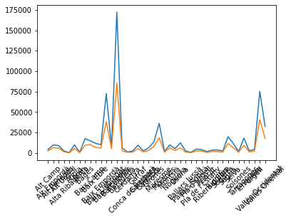

```python
plt.plot(Dones_comarca)
plt.plot(Homes_comarca)
plt.xticks(rotation=45)
plt.show()
```

Así finalizamos la práctica 4